# INFORME DEL SERVICIO/USARIOS

Miguel Angel PC

2024-12-13

## 1.INTRODUCION

En este informe analizaremos los datos del uso de bicicletas y realizaremos un procesamiento detallado para obtener métricas y visualizaciones clave para tomar decisiones en el área de marketing con el fin de incentivar a los usuarios que no cuentan con una membresia a adquirirla.

## 2.LIBRERIAS Y CONFIGURACIÓN

```r
library(tidyverse)
```

```r
library(dplyr)
library(ggplot2)
library(lubridate)
library(tidyr)
```

## 3.IMPORTACION DE DATOS

Se importa los datos que vamos a procesar y analizar.

```r
bicycle_dates <- read.csv("C:/Users/migue/OneDrive/Documentos/Trabajos en R/Proyecto Ciclas/Ciclas.csv")
```

## 4.LIMPIEZA DE DATOS

Procesamos la base de datos en busca de datos duplicados, datos nulos y procedemos a limpiarlos para tener una base de datos más confiable y precisa.Luego ordenamos en orden ascendente por fecha.

También creamos una columna para representar el tipo de usuario con un valor númerico para obtener la mediana y el promedio.

```
## Duplicados; 0
```

```
## Nulos: 382
```

```
## Nulos: 0
```

```
##    rideable_type          started_at member_casual type
## 1  electric_bike 2021-11-01 00:00:14        casual    2
## 2  electric_bike 2021-11-01 00:00:14        casual    2
## 3  electric_bike 2021-11-01 00:01:36        casual    2
## 4  electric_bike 2021-11-01 00:02:27        member    1
## 5   classic_bike 2021-11-01 00:02:35        member    1
## 6   classic_bike 2021-11-01 00:02:36        member    1
## 7  electric_bike 2021-11-01 00:02:58        member    1
## 8  electric_bike 2021-11-01 00:03:13        member    1
## 9  electric_bike 2021-11-01 00:04:13        member    1
## 10 electric_bike 2021-11-01 00:04:32        casual    2
```

```
## Mediana: 1
```

```
## Promedio: 1.297043
```

## 5.ANALISIS Y TRANSFORMACION DE DATOS

Se crea una columna para almacenar el tiempo de uso por cada bicicleta en segundos.

```
##    rideable_type member_casual time_duration
## 1  electric_bike        casual          1796
## 2  electric_bike        casual           232
## 3  electric_bike        casual           488
## 4  electric_bike        member           419
## 5   classic_bike        member           843
## 6   classic_bike        member           521
## 7  electric_bike        member           677
## 8  electric_bike        member           417
## 9  electric_bike        member           645
## 10 electric_bike        casual           425
```

Se crea una columna para convertir los segundos en horas, minutos y segundos.

```
##    rideable_type member_casual     time
## 1  electric_bike        casual 00:29:56
## 2  electric_bike        casual 00:03:52
## 3  electric_bike        casual 00:08:08
## 4  electric_bike        member 00:06:59
## 5   classic_bike        member 00:14:03
## 6   classic_bike        member 00:08:41
## 7  electric_bike        member 00:11:17
## 8  electric_bike        member 00:06:57
## 9  electric_bike        member 00:10:45
## 10 electric_bike        casual 00:07:05
```

Procedemos a calcular la distancia de recorrido.

```
##    rideable_type member_casual     time distance
## 1  electric_bike        casual 00:29:56     8.21
## 2  electric_bike        casual 00:03:52     1.57
## 3  electric_bike        casual 00:08:08     2.08
## 4  electric_bike        member 00:06:59     0.83
## 5   classic_bike        member 00:14:03     1.63
## 6   classic_bike        member 00:08:41     1.36
## 7  electric_bike        member 00:11:17     4.64
## 8  electric_bike        member 00:06:57     0.68
## 9  electric_bike        member 00:10:45     3.56
## 10 electric_bike        casual 00:07:05     2.00
```

Luego procedo a verificar que día de la semana se utlizo el servicio.

```
##    rideable_type member_casual     time distance week_day
## 1  electric_bike        casual 00:29:56     8.21    lunes
## 2  electric_bike        casual 00:03:52     1.57    lunes
## 3  electric_bike        casual 00:08:08     2.08    lunes
## 4  electric_bike        member 00:06:59     0.83    lunes
## 5   classic_bike        member 00:14:03     1.63    lunes
## 6   classic_bike        member 00:08:41     1.36    lunes
## 7  electric_bike        member 00:11:17     4.64    lunes
## 8  electric_bike        member 00:06:57     0.68    lunes
## 9  electric_bike        member 00:10:45     3.56    lunes
## 10 electric_bike        casual 00:07:05     2.00    lunes
```

Por la gran cantidad de datos, se procede a sacar una muestra que represente los datos y tener mejor manejo al graficar la información. También se procede a calcular la mediana y el promedio para verificar que mi muestra es confiable (El valor del promedio puede ser ligeramente diferente al anterior).

```
## Mediana: 1
```

```
## Promedio: 1.29
```

## 6.VISUALIZACIONES

Observamos que las personas que usan el servicio tienden a usar la bicicleta electricas para recorrer mayores distancias.

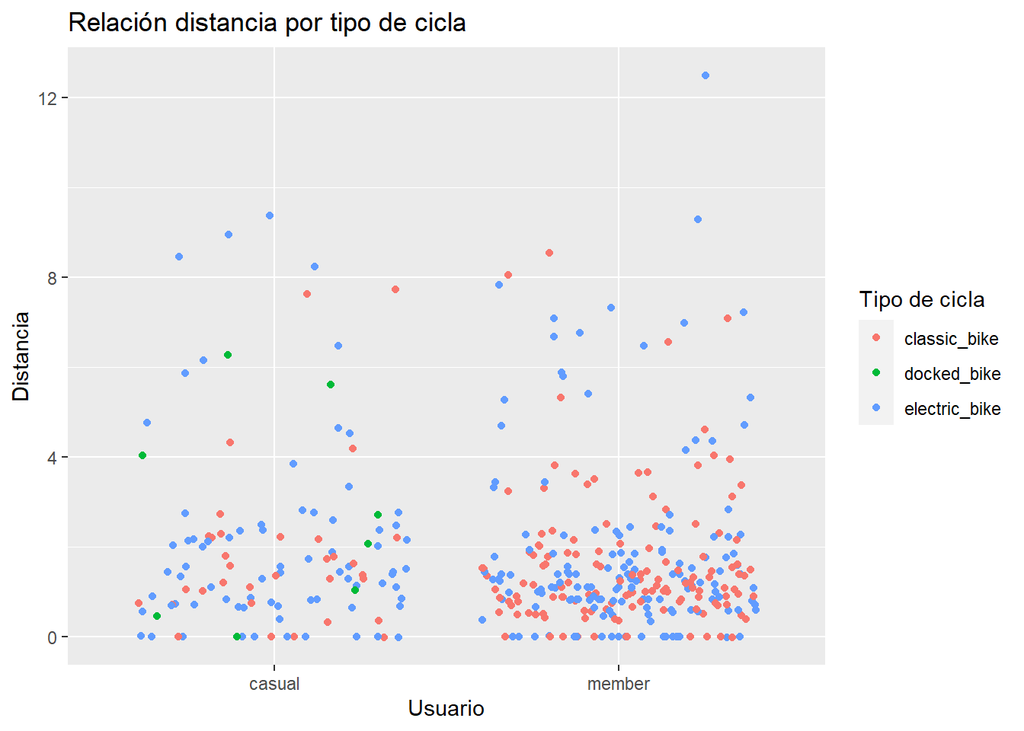

Observamos que los miembros usan más el servicio,, lo usan los primeros días de la semana. Y prefieren usar la cicla electrica.

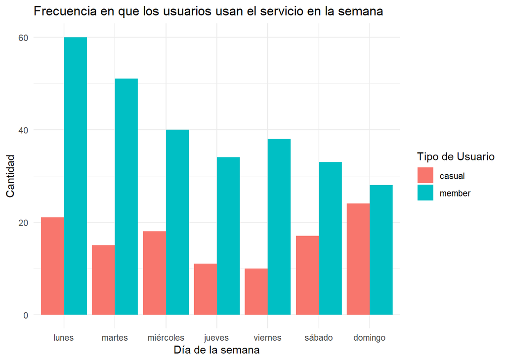

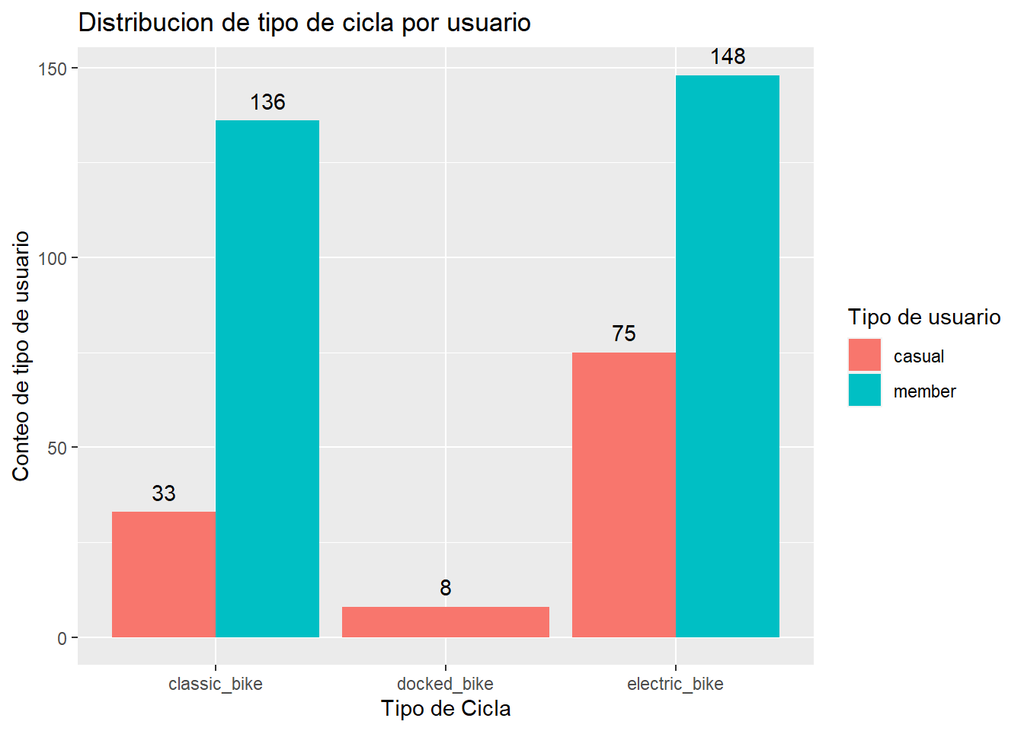

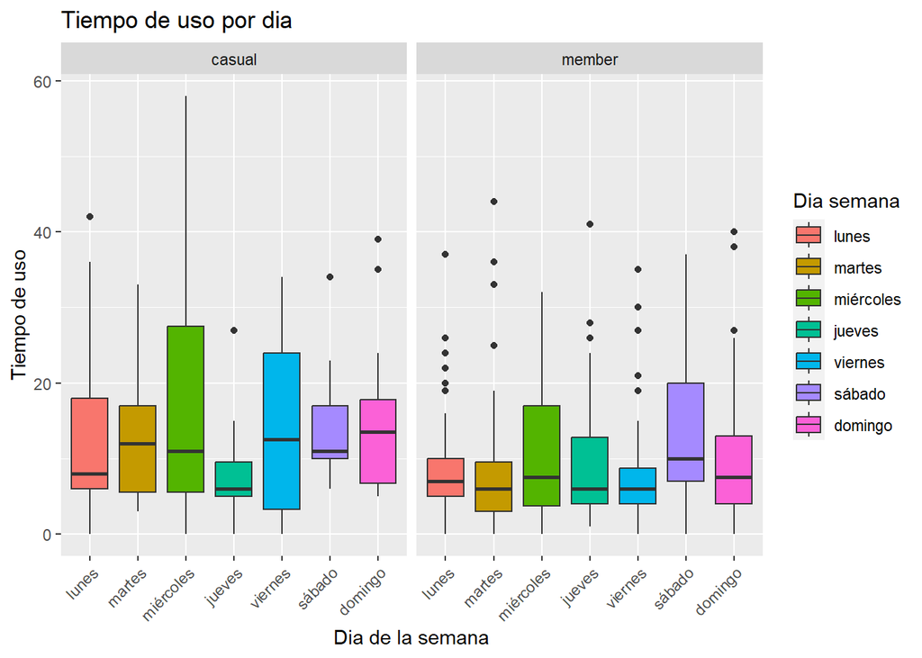

## 7.CONCLUSIONES

-Ofrecer acceso prioritario a las usuarios con membresia.  
-Dar beneficios a los miembros que usen el servicio frecuente en días especificos.  
-Ofrecer mejores tarifas o beneficios a los miembros que recorran largas distancias, incentivandolos a utilizar el servicio con mayor frecuencia.  
-Ofrecer beneficios por antiguedad que premie a los miembros de largo plazo. Lo que fomentaria lealtad y quieran seguir siendo miembros a largo plazo.